# drawer R Markdown demos

Le Zhang

2/28/2021

## Simple usage

{drawer} is compatible with R markdown. If you only want a portable image editting tool, you can do it as simple as:

[figure not shown]

```r
library(drawer)
library(ggplot2) # we will make some plots later
canvas("simple_canvas", rmarkdown = TRUE)
```

drawer

Text Fill color

Text background color

[interactive chart not shown]

## Capture buttons

To capture pictures or plots in the docuemnt to canvas to do further editing:

### `toCanvasBtn`

**1. Create some elements in R markdown with some HTML identifier, like HTML `id`,** **or other advanced CSS selector (read help file `?canvas`).**

Lets create some plots, remeber to create some identifiers for them. In R markdown, the easiest way is to create `id` by adding `out.extra='id="xx"'` tag in your R chunk setting: `{r out.extra='id="plot1"'}`

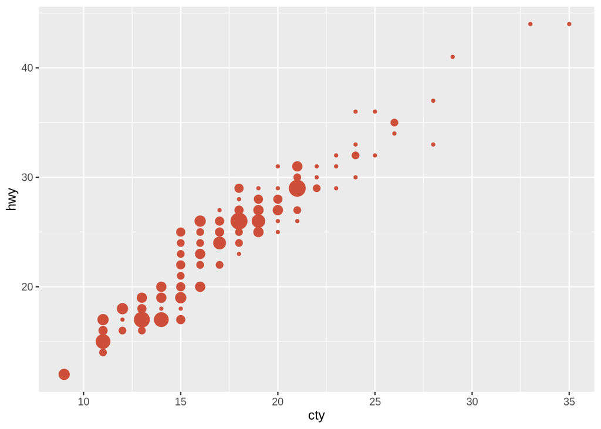

````markdown
```{r echo=FALSE, out.extra='id="plot1"'}
ggplot(mpg, aes(cty, hwy)) +
  geom_count(col="tomato3", show.legend=F)
```
````

**2. Create the capture buttons, or the capture text buttons.**

```r
toCanvasBtn(
  dom = "plot1",
  canvasID = "simple_canvas"
)
```

We are telling the button to capture screenshots of “plot1” and send it to canvas. Now, **click on the button and then scroll back to the canvas**. You should see it has been added to the “Images/Plots” left sidebar. Then, you can simply drag the image from the list to canvas and start your editing.

This button also allows you to download the screenshot as a *png* or *jpg*.

**3. Capture more than just an image**

You can capture any HTML element/chunks to the canvas, for example we have some text in Rmakrdown (for better capture, we also change the display CSS style a little):

#### This is a title in Rmarkdown

some text follows….

- a list
- b
- c

```html
<div id="some_text" style="display:inline-block">
#### This is a title in Rmarkdown
some text follows....

- a list
- b
- c
</div>
```

```r
toCanvasBtn(
  dom = "some_text",
  canvasID = "simple_canvas"
)
```

### `toCanvasTextBtn`

The `toCanvasTextBtn` allows users to capture any elements in current document. So, instead of the author of the Rmarkdown who specifies which element to capture, this time, users/readers can decide what to capture by fill in the text-input.

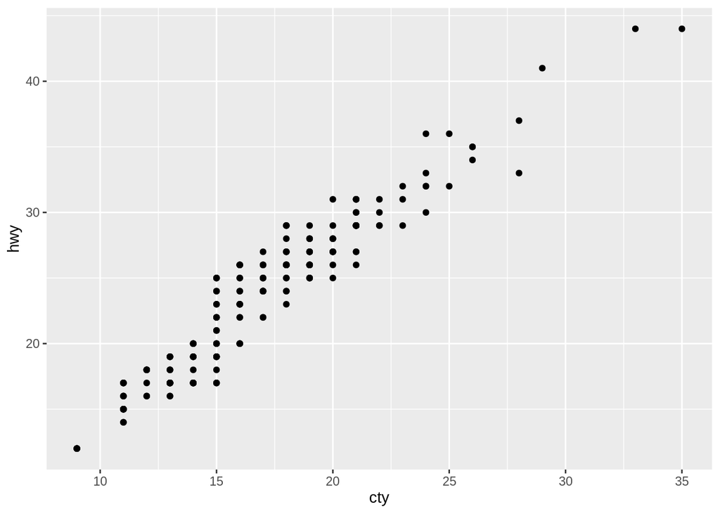

```r
ggplot(mpg, aes(cty, hwy)) +
    geom_point()
```

Another plot with `id='plot2'` has created, now first use the text button group below to capture it.

```r
toCanvasTextBtn(
  canvasID = "simple_canvas",
  text_value = "#plot2",
  style = "width: 50%"
)
```

Then change it to “#plot1” see if you could capture the previous plot by this button.

The thing to notice here is it uses CSS selector, so for `id`, you need to append `#` in front `#element_id`. Of course, you can advanced selectors to select elements that have no `id`. Learn them by Google “CSS selector”.